# R Notebook

```r
library(mgcv)
library(tidyverse)
```

data01 %>% filter(depth == 125) %>% select(lb, binsize, vol, TotalParticles)

https://stats.stackexchange.com/questions/496900/why-are-the-upper-bounds-of-my-poisson-gam-so-high

I am wondering why, when I run a gam with `family = poisson`. I get really large confedence intervals in some cases when I actually see zero particles.

# Background

Here is my situation:

I measured the size and number of particles in a 414 L volume of the ocean.

My data look like this

```r
particles0 <- structure(list(lb = c(0.102, 0.128, 0.161, 0.203, 0.256, 0.323,
0.406, 0.512, 0.645, 0.813, 1.02, 1.29, 1.63, 2.05, 2.58, 3.25,
4.1, 5.16, 6.5, 8.19, 10.3, 13, 16.4, 20.6, 26), binsize = c(0.026,
0.033, 0.042, 0.053, 0.067, 0.083, 0.106, 0.133, 0.168, 0.207,
0.27, 0.34, 0.42, 0.53, 0.67, 0.85, 1.06, 1.34, 1.69, 2.11, 2.7,
3.4, 4.2, 5.4, 6), vol = c(413.6, 413.6, 413.6, 413.6, 413.6,
413.6, 413.6, 413.6, 413.6, 413.6, 413.6, 413.6, 413.6, 413.6,
413.6, 413.6, 413.6, 413.6, 413.6, 413.6, 413.6, 413.6, 413.6,
413.6, 413.6), TotalParticles = c(1596, 513, 571, 211, 131, 84,
36, 18, 12, 5, 3, 1, 0, 0, 0, 0, 0, 0, 0, 0, 0, 0, 0, 0, 0)), class = c("tbl_df",
"tbl", "data.frame"), row.names = c(NA, -25L))
```

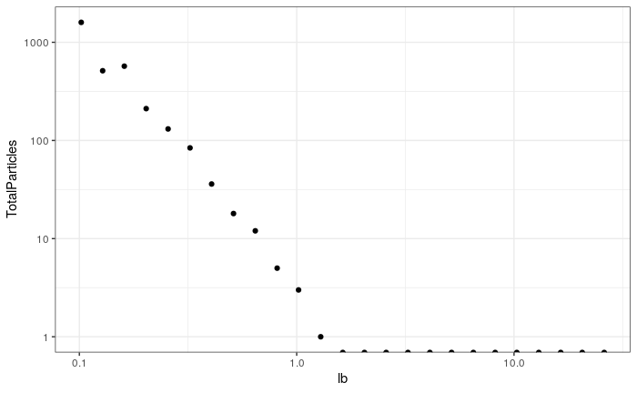

```r
ggplot(particles0, aes(x = lb, y = TotalParticles)) + geom_point() + scale_y_log10() + scale_x_log10() + theme_bw()
```

You can see that there are lots of small particles and fewer big ones.

Also, we don’t see any particles bigger than 1.29. For various reasons, I’d like to extrapolate the number of particles larger than 1.29 using a glm and gam model.

If I normalize the number of particles to volume and size, I expect them to follow a more or less linear distribution.

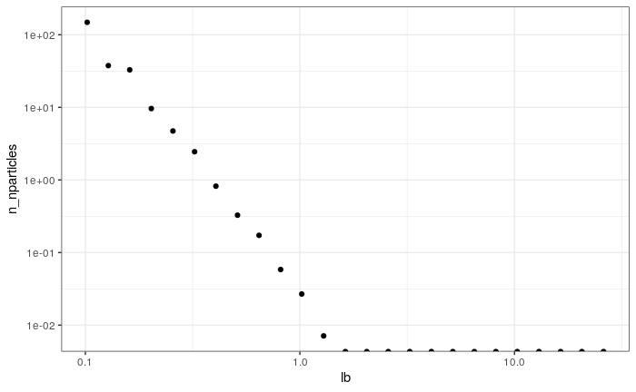

```r
particles <- particles0 %>% mutate(nparticles = TotalParticles/vol, n_nparticles = nparticles/binsize)
ggplot(particles, aes(x = lb, y = n_nparticles)) + geom_point() + scale_y_log10() + scale_x_log10() + theme_bw()
```

This figure looks similar to the one above, but these generally and actually tend to be more linear.

# GLM

The first model that I built was a poisson glm and I used it to extrapolate values with confedence intervals.

```r
# family was poisson
my_glm <- function(df){
  glm(TotalParticles ~ log(lb), offset = log(vol * binsize), family = quasipoisson, data = df)
}

modGlm <- my_glm(particles)
predGlm <- predict(modGlm, type = "link", se.fit = TRUE) %>% as_tibble
```

```r
## Bind the model estemates to the actual data and estemate confedence intervals
particles_01 <- bind_cols(particles, predGlm) %>%
  rename(glmFit = fit, glmSE = se.fit) %>%
  ## estemate lower and upper confedence intervals, in link space
  mutate(glmLower = glmFit - 2 * glmSE, glmUpper = glmFit + 2 * glmSE) %>%
  ## Translate into response space
  mutate(glmTP = exp(glmFit), glmTPLower = exp(glmLower), glmTPUpper = exp(glmUpper))
```

I’m not sure why I don’t have to address the offsets here to get back into total particle space, but emperically it doesn’t seem to be necessary.

Here I show total particles, against their fitted values

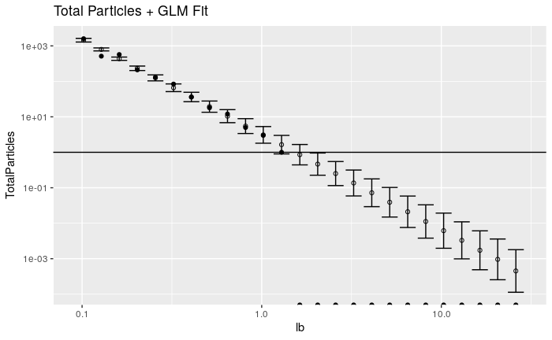

```r
particles_01 %>% ggplot(aes(x = lb)) +
  ## Actual Data (Solid Circles)
  geom_point(aes(y = TotalParticles)) +
  ## Modelled Linear Fit
  geom_point(aes(y = glmTP), shape = 1) +
  geom_errorbar(aes(ymin = glmTPLower, ymax = glmTPUpper)) +
  scale_x_log10() + scale_y_log10() + labs(title = "Total Particles + GLM Fit") +
  geom_hline(yintercept = 1)
```

Here I show normalized values vs fitted predictions.

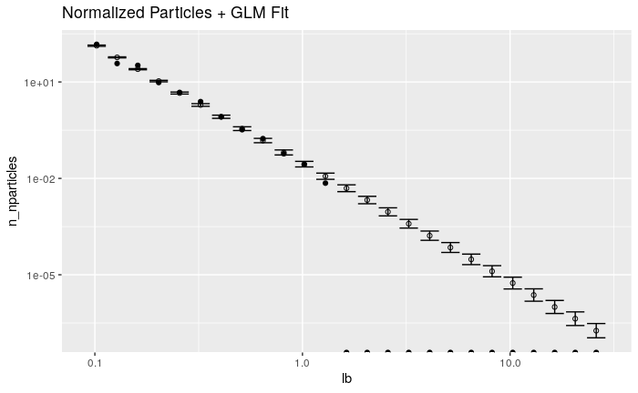

```r
particles_01 %>% ggplot(aes(x = lb)) +
  ## Actual Data (Solid Circles)
  geom_point(aes(y = n_nparticles)) +
  ## Modelled Linear Fit
  geom_point(aes(y = glmTP/vol/binsize), shape = 1) +
  geom_errorbar(aes(ymin = glmTPLower/vol/binsize, ymax = glmTPUpper/vol/binsize)) +
  scale_x_log10() + scale_y_log10() + labs(title = "Normalized Particles + GLM Fit")
```

This generally seems reaosonable to me. Its a line, in log-log space. When we see zeros, we have estemates of true values that are less than one. Thus these seem like ok predictions if I assume a power law relationship between particle size and normalized particle number.

There are a few things I don’t love. 1 - Those confedence intervals are suspiciously small as we get into the larger particle sizes. 2 - There’s a little bendyness to the actual points that the data that I’d like to allow for. This is especially the problem in some other sets of these data.

# GAM

Klaus: what is quasipoisson Library gamlss (don’t use the lss part) In gam universe. Is it converging on the same thing as poisson. How valid is poisson assumption. Look at help page on selecting gams Maybe compare summaries of nb, quasipoisson and linear and smooth I might be able to use a compound gam.

Smoothing method may depend on scale, find one that doesn’t. The standard s doesn’t but others might work.

> gamBoth <- gam(TotalParticles ~ (log(lb)) + s(log(lb)), offset = log(vol * binsize), family = nb(), data = particles) summary(gamBoth)

One thing I tried was doing a poisson gam instead. This allows for some bendyness which should allow the confedence intervals to be larger for the larger particles, and also fit the small particles a little better too.

```r
# was poisson
my_gam <- function(df){
  gam(TotalParticles ~ s(log(lb)), offset = log(vol * binsize), family = nb(), data = df)
}

modGam <- my_gam(particles)
predGam <- predict(modGam, type = "link", se.fit = TRUE) %>% as_tibble
```

```r
particles_02 <- bind_cols(particles, predGam) %>%
  rename(gamFit = fit, gamSE = se.fit) %>%
  ## estemate lower and upper confedence intervals, in link space
  mutate(gamLower = gamFit - 2 * gamSE, gamUpper = gamFit + 2 * gamSE) %>%
  ## Translate into response space
  mutate(gamTP = exp(gamFit), gamTPLower = exp(gamLower), gamTPUpper = exp(gamUpper))
```

Unlike the glm, these end up in units of n_nparticles. Again, I determined this emperically.

I translate everything back into total particle space first in this case.

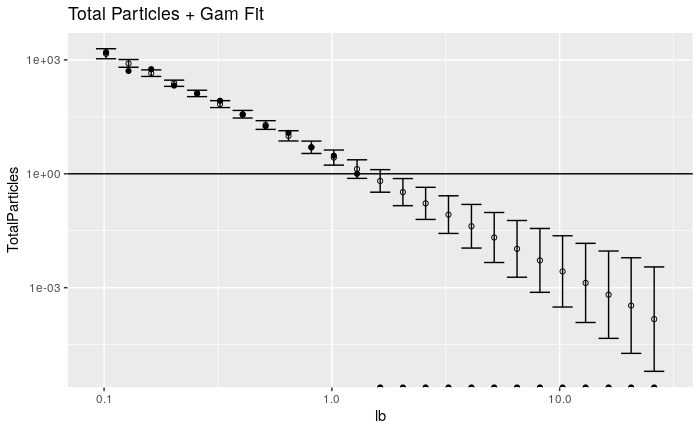

```r
particles_02 %>% ggplot(aes(x = lb)) +
  ## Actual Data (Solid Circles)
  geom_point(aes(y = TotalParticles)) +
  ## Modelled Linear Fit
  geom_point(aes(y = gamTP * vol * binsize), shape = 1) +
  geom_errorbar(aes(ymin = gamTPLower * vol * binsize, ymax = gamTPUpper * vol * binsize)) +
  scale_x_log10() + scale_y_log10() + labs(title = "Total Particles + Gam Fit") +
  geom_hline(yintercept = 1)
```

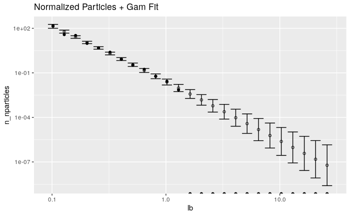

```r
particles_02 %>% ggplot(aes(x = lb)) +
  ## Actual Data (Solid Circles)
  geom_point(aes(y = n_nparticles)) +
  ## Modelled Linear Fit
  geom_point(aes(y = gamTP), shape = 1) +
  geom_errorbar(aes(ymin = gamTPLower, ymax = gamTPUpper)) +
  scale_x_log10() + scale_y_log10() + labs(title = "Normalized Particles + Gam Fit")
```

Thanks for any advice.